# EDAV Fall 2019 PSet 4

Read *Graphical Data Analysis with R*, Ch. 9, 11

Read *Interactive Data Visualization for the Web*, Ch. 3, 5

The theme of this problem set is freedom. As you will see, you’ll have more choices than usual in terms of data and packages.

Remember that you are expected to meet with your partner in person–even if you are working on different parts there is a benefit to having someone to ask questions to or spot the typo in your code. You are also expected to communicate frequently, pull your weight, and not make unilateral decisions. It’s all about collaboration and partnership.

Grading is based both on your graphs and verbal explanations. Follow all best practices as discussed in class.

### 1. Missing values

You may choose your own data. The only requirement is that it has some missing values. If the dataset is large, you may choose to work with only some of the columns and a random selection of rows.

Use any R plotting package (`ggplot2`, `naniar`, `mi`, `extracat`, etc.) to answer the following questions. (Note that `extracat` is not currently on CRAN but you can install it from a CRAN read-only mirror on GitHub: https://github.com/cran/extracat)

1. Visualize and describe missing column patterns. Which variable has the highest number of missing values?

```r
library(visdat)
library(naniar)
library(ggplot2)
library(dplyr)
library(parcoords)

newdf <- airquality
newdf <- newdf[sample(nrow(newdf), 30), ]
#Printing number of missing values by column
colSums(is.na(newdf)) %>%sort(decreasing =TRUE)
```

```
##   Ozone Solar.R    Wind    Temp   Month     Day
##      12       2       0       0       0       0
```

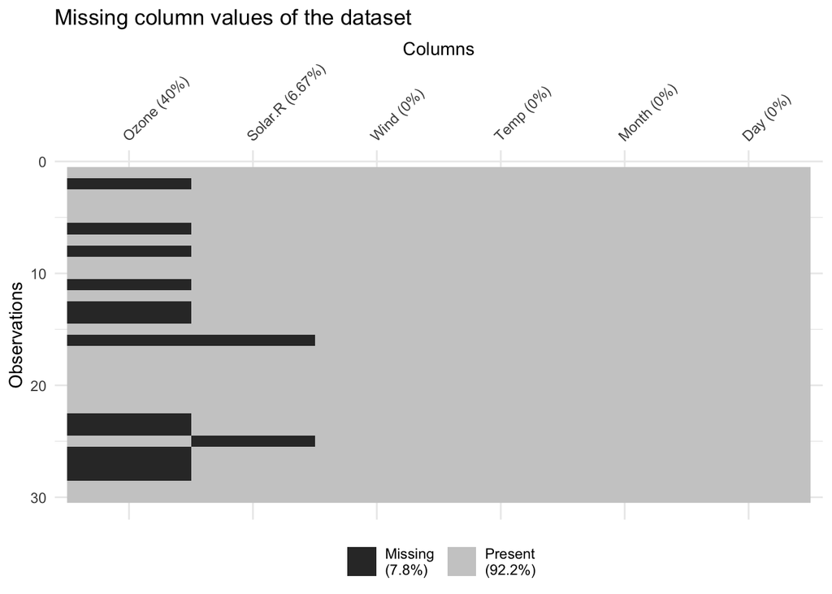

```r
#Visualizing missing values in columns as they appear in the data frame (PLOT 1)
vis_miss(newdf) + ggtitle("Missing column values of the dataset") + xlab("Columns")
```

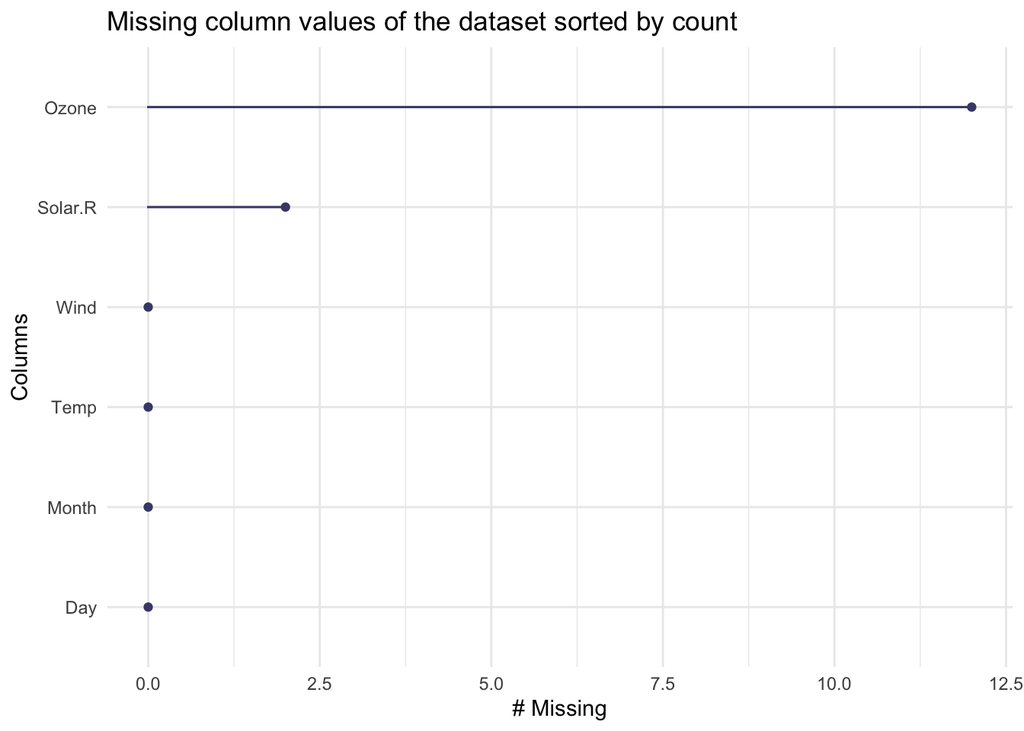

```r
#Visualizing count of missing values by columns (PLOT 2)
gg_miss_var(newdf)+ ggtitle("Missing column values of the dataset sorted by count") + xlab("Columns")
```

2. Visualize and describe missing row patterns. Which row has the highest number of missing values?

```r
newdf1 <- data.frame(t(newdf))
colnames(newdf1) <- c(1:30)
#Printing number of missing values by row
rowSums(is.na(newdf)) %>%sort(decreasing =TRUE)
```

```
##  27  60  10  83  36 115  84  61 150  11  55  46  56  73 143 130  41 136
##   2   1   1   1   1   1   1   1   1   1   1   1   1   0   0   0   0   0
##  68 123  79 153  86  29  13 126 124 113 144 122
##   0   0   0   0   0   0   0   0   0   0   0   0
```

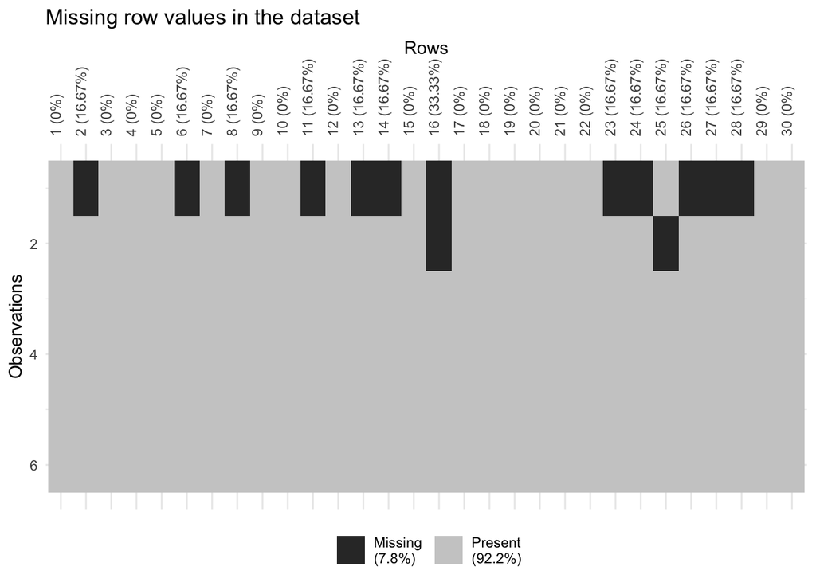

```r
#Visualizing missing values in rows as they appear in the data frame
vis_miss(newdf1) + ggtitle("Missing row values in the dataset") + xlab("Rows") +
  theme(axis.text.x = element_text(angle = 90))
```

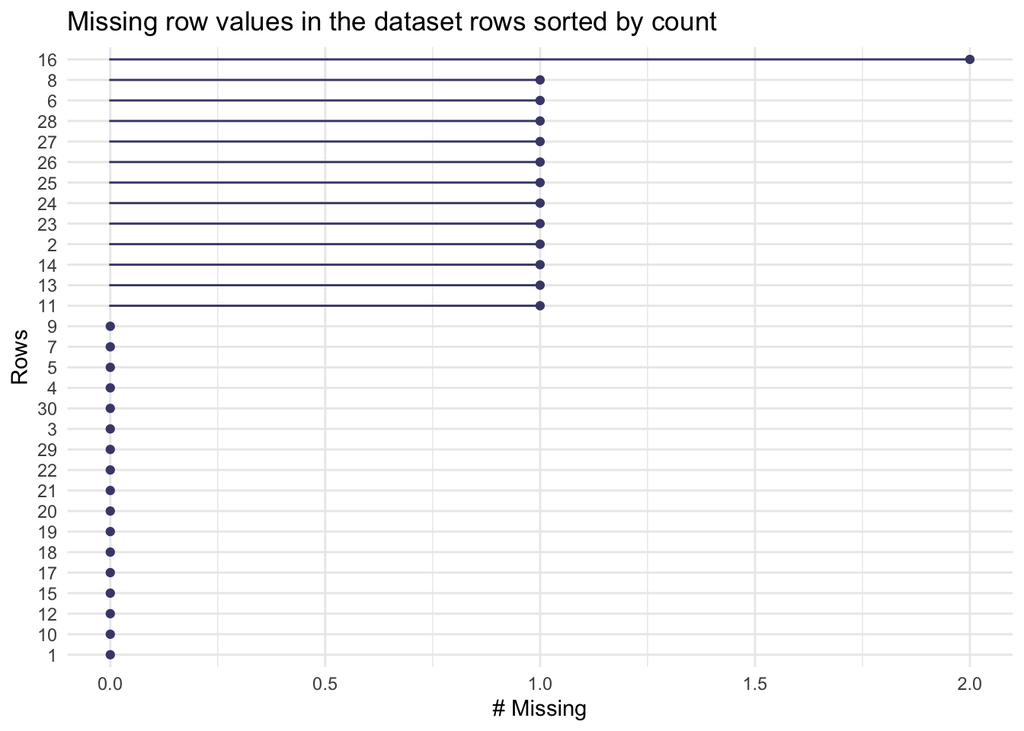

```r
#Visualizing count of missing values by rows
gg_miss_var(newdf1)+ ggtitle("Missing row values in the dataset rows sorted by count") +xlab("Rows")
```

3. Do correlations exist between the values of other variables and missing patterns? Investigate two missing patterns and draw conclusions such as:

“The number of missing values for the `last sale price` column seems to be correlated with `average income in zipcode`: there are more missing values in `last sale price` for homes in low-income neighborhoods.”

“There does not seem to be any correlation between `apartment type` and missing values in `last sale price`”

Support your conclusions with graphs.

There seems to be a correlation between the missing values and the month. Many values of Ozone are missing around the month of June (6th month). This can be seen in the first graph and second graph.

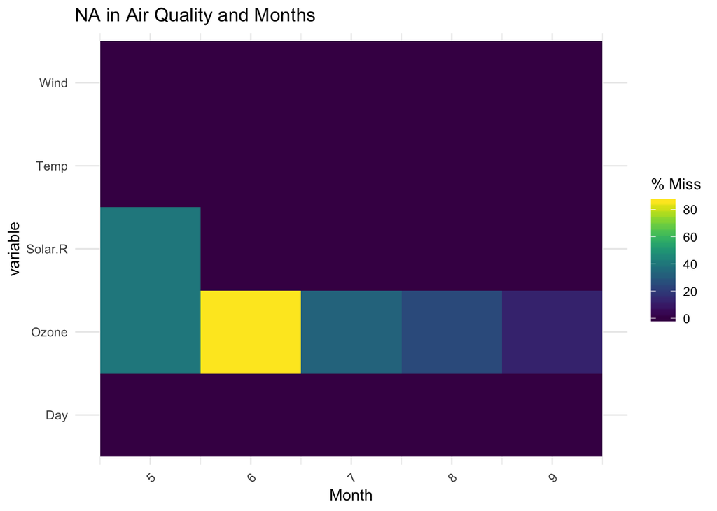

```r
gg_miss_fct(x = newdf, fct = Month ) + labs(title = "NA in Air Quality and Months") #GRAPH 1
```

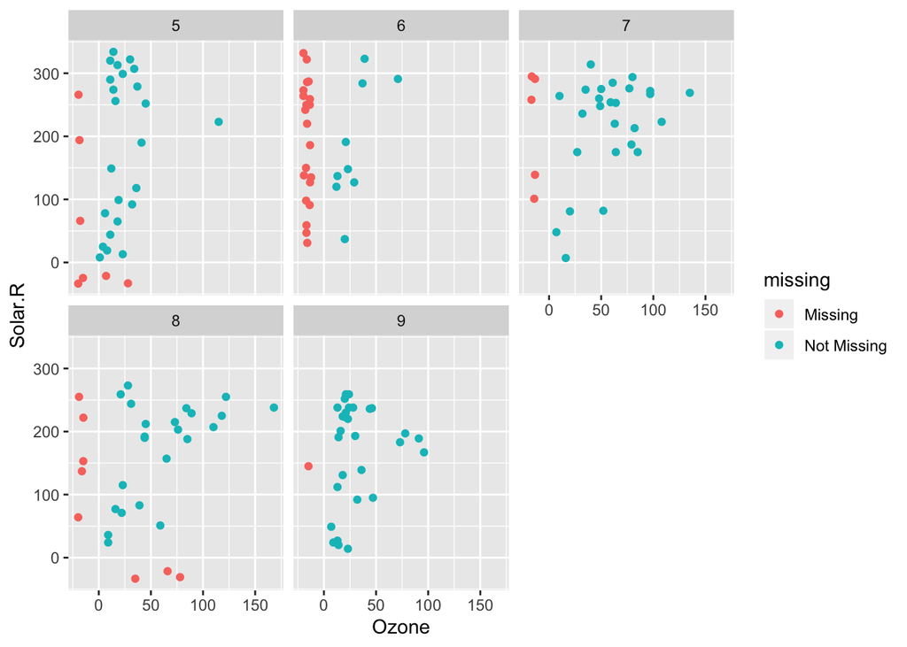

```r
ggplot(airquality, #GRAPH 2
       aes(x = Ozone,
           y = Solar.R)) +
  geom_miss_point() +
  facet_wrap(~Month)
```

There seems to be a weak correlation between missing values of ozone and the temperature. There seem to be missing ozone values for higher temperatures. This can be seen in graphs 3 and 4.

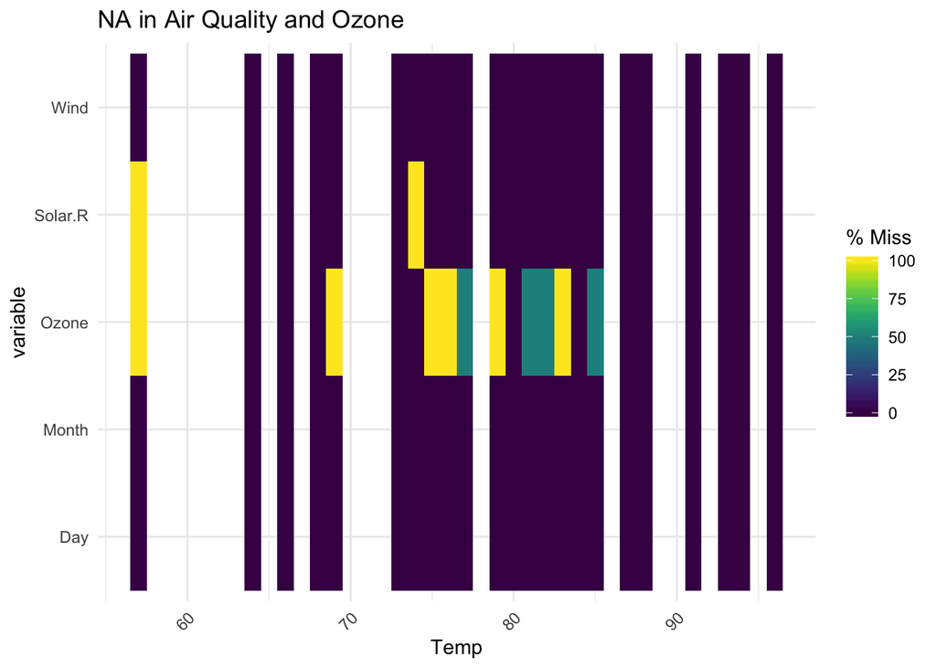

```r
gg_miss_fct(x = newdf, fct = Temp ) + labs(title = "NA in Air Quality and Ozone") #GRAPH 3
```

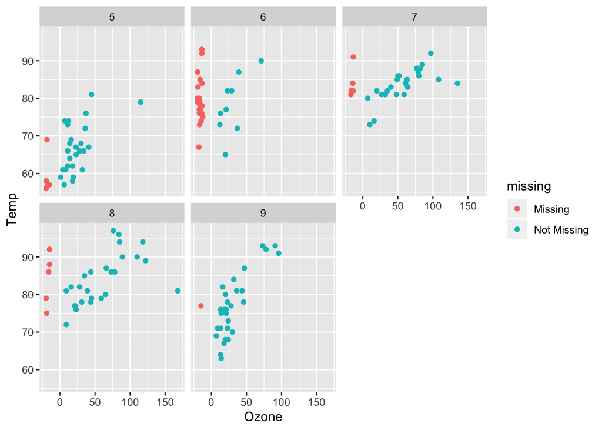

```r
ggplot(airquality, #GRAPH 4
       aes(x = Ozone,
           y = Temp)) +
  geom_miss_point() +
  facet_wrap(~Month)
```

### 2. Time Series

1. Use the **tidyquant** package to collect information on anything other than stock prices for which time series data is available. Create a multiple line chart to compare trends over time. Your chart should have at least 3 lines.

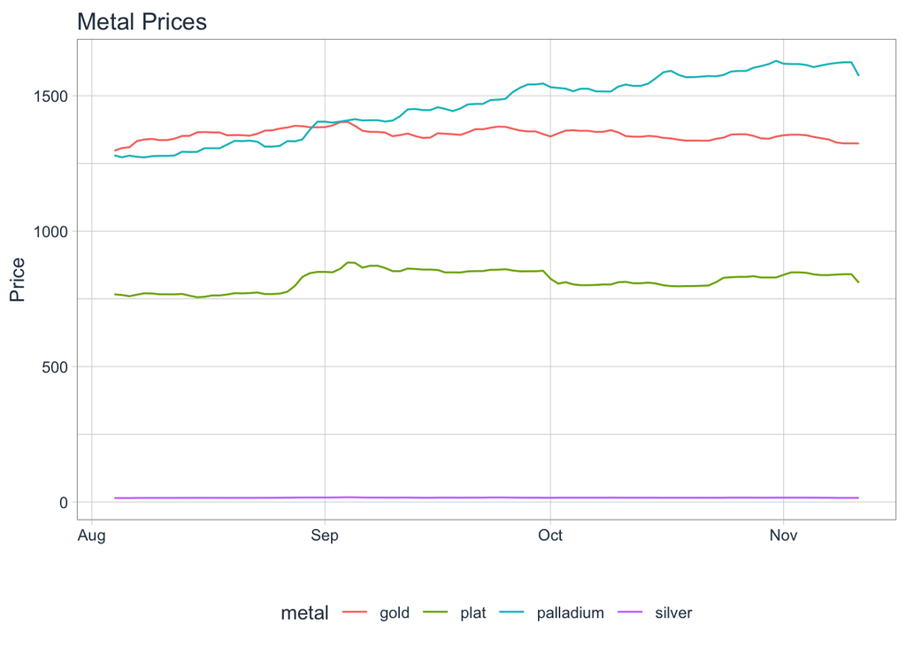

```r
library(tidyquant)
library(ggplot2)
library(reshape2)

price <- tq_get("gold", get = "metal.prices",
                         from = Sys.Date() - lubridate::days(100), base.currency = "EUR")
colnames(price)[colnames(price)=="price"] <- "gold"
plat_price <- tq_get("plat", get = "metal.prices",
                     from = Sys.Date() - lubridate::days(100), base.currency = "EUR")
price$plat=plat_price$price
pd_price <- tq_get("palladium", get = "metal.prices",
                     from = Sys.Date() - lubridate::days(100), base.currency = "EUR")
price$palladium=pd_price$price
silver_price <- tq_get("silver", get = "metal.prices",
                   from = Sys.Date() - lubridate::days(100), base.currency = "EUR")
price$silver=silver_price$price

metalprices <- melt(price, id = c("date"), variable.name = "metal", value.name = "price")

metalprices %>%
  ggplot(aes(date, y = price, colour = metal, group = metal)) +
  geom_line() +
  labs(title = "Metal Prices", y = "Price", x = "") +
  theme_tq()
```

This chart can help us compare prices of 4 metal namely gold, platinum, silver and palladium over time (August to November). We can observe the trends : Palladium is the highest priced metal, followed by gold, platinum and silver although initially gold was priced more than palladium brielfy during the month of august. Prices of silver have not changed much over time but palladium prices seem to rise constantly and gold and platinum see slight ups and downs but largely remain at the same level.

2. Transform the data so each series begins at 100 and replot. (see Unwin, p. 229)

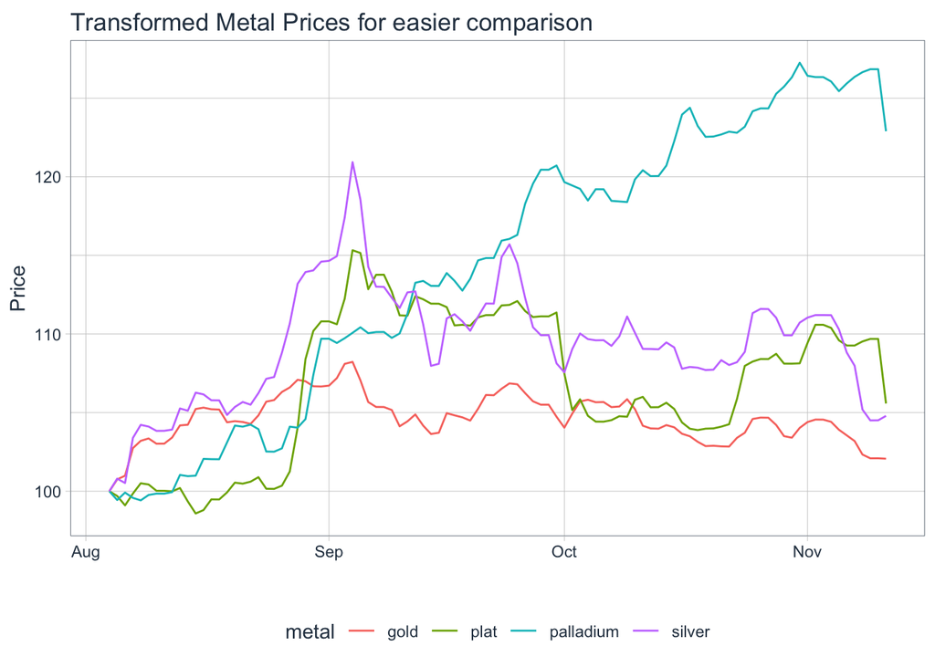

```r
newmetalprices <- lapply(select(price, -date), function(x) 100*x/x[1])
newmetalprices <- cbind(date = price$date, as.data.frame(newmetalprices))
newmetalprices <- melt(newmetalprices, id="date", variable.name="metal", value.name="price")
newmetalprices %>%
  ggplot(aes(date, y = price, colour = metal, group = metal)) +
  geom_line() +
  labs(title = "Transformed Metal Prices for easier comparison", y = "Price", x = "") +
  theme_tq()
```

(c) Compare the graphs in (a) and (b).

From August, Palladium has seen a steady growth. Platinum started poorly but quickly grew in price by september. Silver grew in rate the fastest but also fell down soon after in price in a month’s time. Gold has been all right in it’s price growth although it seems to show a slight decreasing trend at times generally.

### 3. Cause of Death

Data: https://wonder.cdc.gov/ucd-icd10.html

1. Create a series of choropleth maps in which only one variable changes, such as level of a factor variable or time.

For inspiration, see these examples:

https://www.nytimes.com/interactive/2017/06/30/upshot/the-best-and-worst-new-york-neighborhoods.html

https://www.nytimes.com/interactive/2017/10/05/upshot/gun-ownership-partisan-divide.html

```r
library(tidyverse)
library(readr)
deaths = read_tsv("./PSet4-data/Overdose-1999-2017.txt")
head(deaths)
```

```
## # A tibble: 6 x 8
##   Notes State `State Code`  Year `Year Code` Deaths Population `Crude Rate`
##   <chr> <chr> <chr>        <dbl>       <dbl>  <dbl>      <dbl> <chr>
## 1 <NA>  Alab… 01            1999        1999    195    4430141 4.4
## 2 <NA>  Alab… 01            2000        2000    232    4447100 5.2
## 3 <NA>  Alab… 01            2001        2001    253    4467634 5.7
## 4 <NA>  Alab… 01            2002        2002    248    4480089 5.5
## 5 <NA>  Alab… 01            2003        2003    255    4503491 5.7
## 6 <NA>  Alab… 01            2004        2004    327    4530729 7.2
```

```r
deaths_1999 = deaths %>%
    filter(Year == 1999) %>%
    group_by(State) %>%
    summarise(Deaths = sum(Deaths)) %>%
    ungroup()
#print(deaths_1999)
df = deaths %>%
    filter(Year %in% c(2002, 2005, 2008, 2011, 2014, 2017)) %>%
    group_by(Year, State) %>%
    summarise(Deaths = sum(Deaths), Population = sum(Population)) %>%
    ungroup() %>%
    left_join(y = deaths_1999, by = "State", suffix = c("", "_1999")) %>%
    mutate(State = tolower(State), Deaths_per_Thousands = 100000*Deaths/Population, Deaths_Change = (Deaths - Deaths_1999)/Deaths_1999)
head(df)
```

```
## # A tibble: 6 x 7
##    Year State  Deaths Population Deaths_1999 Deaths_per_Thou… Deaths_Change
##   <dbl> <chr>   <dbl>      <dbl>       <dbl>            <dbl>         <dbl>
## 1  2002 alaba…    248    4480089         195             5.54         0.272
## 2  2002 alaska     85     642337          56            13.2          0.518
## 3  2002 arizo…    667    5396255         557            12.4          0.197
## 4  2002 arkan…    190    2705927         121             7.02         0.570
## 5  2002 calif…   3418   34871843        3091             9.80         0.106
## 6  2002 color…    474    4490406         375            10.6          0.264
```

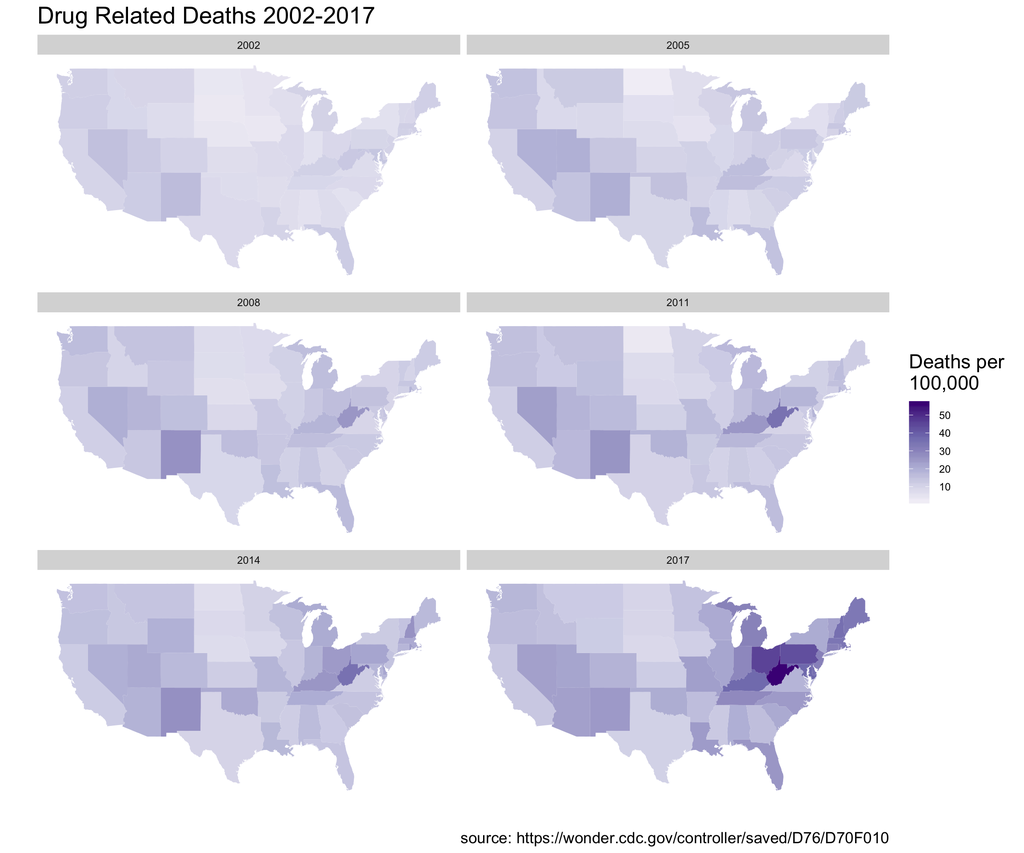

```r
library(tidyverse)
library(maps)
library(ggplot2)

usa <- map_data("usa")
states <- map_data("state")

ggplot(df, aes(map_id = State)) +
  geom_map(aes(fill = Deaths_per_Thousands), map = states) +
  expand_limits(x = states$long, y = states$lat) +
  scale_fill_distiller(type = "seq", palette = "Purples", direction = 1, na.value = "white", name = "Deaths per\n100,000") +
  coord_fixed(1.3) +
  facet_wrap(~Year, ncol = 2) +
  labs(
    title = "Drug Related Deaths 2002-2017",
    x = "",
    y = "",
    caption = "source: https://wonder.cdc.gov/controller/saved/D76/D70F010"
  ) +
  theme(
    title = element_text(size = rel(1.5)),
    panel.background = element_blank(),
    axis.ticks = element_blank(),
    axis.text = element_blank()
  )
```

2. Interpret the graphs you drew in (a).

The visualization shows the progression of the opioid crisis in the United States, and the states most affected. While in 2002 and 2005 there was relatively little change, starting with 2008 West Virginia starts to climb in the drug related deaths, and by 2017 West Virginia is the leading state in this crisis with 56.3 drug related deaths per 100,000. The states nearing West Virginia are also highly affected, Ohio (45.4 per 100,000), Pensilvania (42.9 per 100,000) and Kentucky (37.3 per 100,000). There is a perseptibly large increase in deaths in the WV/OH/KY/PA area from 2014 to 2017. There is a secondary area in New England (ME/NH/MA) with a large increase of drug related deaths from 2014 to 2017.

### 4. Mosaic plot (SVG / D3)

1. Manually create a 2 x 2 mosaic plot of party affiliation by gender for (House) representatives currently in the U.S. Congress using SVG. Data is available here in `.csv` form: https://github.com/unitedstates/congress-legislators

You may remove any Independents.

The SVG should be 500 x 400 pixels and included in your `.Rmd` file between svg tags (**not** in a code chunk):

The axes and levels of each variable should be labeled.

(Don’t despair, this is the only time you will have to create SVG by hand for this class!)

```r
library(tidyverse)
congress_legislators = read_csv("https://theunitedstates.io/congress-legislators/legislators-current.csv")

df = congress_legislators %>%
  filter(type == 'rep') %>% # Only House representatives
  filter(party != "Independent") # Excluding Independents

ctable = table(df$gender, df$party)
gender = rowSums(ctable)
t = cbind(ctable/gender, all = gender/sum(gender))
t = 100*t

print(t)
```

```
##   Democrat Republican      all
## F 85.84906   14.15094 24.25629
## M 44.41088   55.58912 75.74371
```

2. Change your code from (a) so that with the exception of the blank SVG, the mosaic plot is completely created with D3, based on a dataset that you provide that contains the 4 values you calculated for part (a). Your code should work if the values change.
2. Use the **r2d3** package. The setup here is different. You will create your visualization in a `.js` file and then call it from an R chunk. More information is available on the package site: https://rstudio.github.io/r2d3/ (Note that you no longer need the preview version of RStudio.) If you use **r2d3**, please erase the template code in i.

```r
data = df %>%
  group_by(gender, party) %>%
  summarise(Freq = n()) %>%
  ungroup()
r2d3::r2d3("d3_congress_mosaic.js", data=data)
```

[interactive chart not shown]